# Swiftkey_Capstone_Milestone

Mingda Wang

Jun 11 2018

# Initial Setup

Packages: knitr, text2vec, tokenizers, stopwords, wordcloud Locale: English Eval, Echo: True Seed: 12221

```r
library("knitr")
library("text2vec")
library("tokenizers")
library("stopwords")
library("wordcloud")
Sys.setlocale("LC_ALL","English")
```

```
## [1] "LC_COLLATE=English_United States.1252;LC_CTYPE=English_United States.1252;LC_MONETARY=English_United States.1252;LC_NUMERIC=C;LC_TIME=English_United States.1252"
```

```r
opts_chunk$set(eval = TRUE, echo = TRUE)
set.seed(12221)
```

# Goal

The purpose of this document is to briefly summarize the main characteristics of the training data and outline the algorithm for the final word prediction data product.

Training data was downloaded from the link provided in the course: https://d396qusza40orc.cloudfront.net/dsscapstone/dataset/Coursera-SwiftKey.zip

Note: All this study has been centered in the US English corpus.

# Data Exploration

## Prepare the Data

While trying to load the data into R on Windows, there seems to be problems on how R on Windows handles special characters. The most troubles resulted from x00(NUL) and x1a(SUB) characters. Because it is slow and tedious to do the replacement on R, I have made a Python script to replace all NUL and SUB characters in all English text files.

The Python script can be found at [here](https://github.com/wanv1171/Data_Science_Capstone/blob/master/remove_special_chars.py)

The Python script includes only ascii_letters, ascii_digits, whitespaces. All special characters such as !“#$%&'()*+,-./:;<=>?@[\]^_`{|}~ are replaced by a whitespace.

## Loading Data

The below script will load the data and also remove lines that are empty.

```r
filePath <- "D:/Documents/R/final/en_US/"

twitterFile <- "en_US.twitter.txt"
blogsFile <- "en_US.blogs.txt"
newsFile <- "en_US.news.txt"


fileToChr <- function(filename) {
  fileCon <- file(paste(filePath, filename, sep=""))
  chrVec <- readLines(fileCon)
  close(fileCon)
  return(chrVec)
}

twitterData <- fileToChr(twitterFile)
twitterData <- twitterData[twitterData != ""]

blogsData <- fileToChr(blogsFile)
blogsData <- blogsData[blogsData != ""]

newsData <- fileToChr(newsFile)
newsData <- newsData[newsData != ""]

fileInfo <- data.frame("Filename" = c(twitterFile, blogsFile, newsFile),
                       "Num Lines" = c(length(twitterData), length(blogsData), length(newsData)))

print(fileInfo)
```

```
##            Filename Num.Lines
## 1 en_US.twitter.txt   2360148
## 2   en_US.blogs.txt    899188
## 3    en_US.news.txt   1010241
```

## Create Training and Testing Datasets

```r
twitterInTrain <- sample(length(twitterData), length(twitterData) * 0.8)
twitterTrain <- twitterData[twitterInTrain]
twitterTest <- twitterData[-twitterInTrain]

blogsInTrain <- sample(length(blogsData), length(blogsData) * 0.8)
blogsTrain <- blogsData[blogsInTrain]
blogsTest <- blogsData[-blogsInTrain]

newsInTrain <- sample(length(newsData), length(newsData) * 0.8)
newsTrain <- newsData[newsInTrain]
newsTest <- newsData[-newsInTrain]
```

## Save Training and Testing Datasets

```r
writeLines(twitterTrain, con="D:/Documents/R/final/en_US/twitter_Train.txt")
writeLines(twitterTest, con="D:/Documents/R/final/en_US/twitter_Test.txt")

writeLines(blogsTrain, con="D:/Documents/R/final/en_US/blogs_Train.txt")
writeLines(blogsTest, con="D:/Documents/R/final/en_US/blogs_Test.txt")

writeLines(newsTrain, con="D:/Documents/R/final/en_US/news_Train.txt")
writeLines(newsTest, con="D:/Documents/R/final/en_US/news_Test.txt")
```

## Remove Useless Variables

```r
rm(blogsData)
rm(twitterData)
rm(newsData)

rm(blogsFile)
rm(newsFile)
rm(twitterFile)

rm(twitterInTrain)
rm(blogsInTrain)
rm(newsInTrain)

rm(twitterTest)
rm(blogsTest)
rm(newsTest)

rm(filePath)
rm(fileToChr)
rm(fileInfo)

gc()
```

```
##            used  (Mb) gc trigger  (Mb)  max used  (Mb)
## Ncells  4951226 264.5    9352480 499.5   7086814 378.5
## Vcells 74283194 566.8  112653140 859.5 110131350 840.3
```

## Data Characteristics

```r
twitterLineLen <- sapply(twitterTrain, FUN=nchar, USE.NAMES = FALSE)
blogsLineLen <- sapply(blogsTrain, FUN=nchar, USE.NAMES = FALSE)
newsLineLen <- sapply(newsTrain, FUN=nchar, USE.NAMES = FALSE)
```

### Twitter Characters per Document Data

```r
summary(twitterLineLen)
```

```
##    Min. 1st Qu.  Median    Mean 3rd Qu.    Max.
##    2.00   37.00   64.00   68.61  100.00  140.00
```

### Blogs Characters per Document Data

```r
summary(blogsLineLen)
```

```
##    Min. 1st Qu.  Median    Mean 3rd Qu.    Max.
##     1.0    46.0   155.0   228.8   327.0 40832.0
```

### News Characters per Document Data

```r
summary(newsLineLen)
```

```
##    Min. 1st Qu.  Median    Mean 3rd Qu.    Max.
##     1.0   109.0   184.0   200.9   267.0 11384.0
```

## Term Vectorization

```r
twitterIoK <- itoken(twitterTrain,
                     preprocessor = tolower,
                     tokenizer = tokenize_words,
                     progressbar = FALSE)

twitterVocab <- create_vocabulary(twitterIoK)

print(tail(twitterVocab, 5))
```

```
## Number of docs: 1888118
## 0 stopwords:  ...
## ngram_min = 1; ngram_max = 1
## Vocabulary:
##    term term_count doc_count
## 1:  you     480940    381535
## 2:    a     491336    415789
## 3:   to     631186    517960
## 4:    i     733656    549626
## 5:  the     749916    583407
```

We can see from above that the most frequently used words are “you, a, i, to, the”, these common words are usually called stop words. Since these words are so common, it makes less sense when we trying to figure our the most used words. ## Remove Stopwords

```r
twitterVocab <- create_vocabulary(twitterIoK, stopwords = stopwords())

print(tail(twitterVocab, 5))
```

```
## Number of docs: 1888118
## 175 stopwords: i, me, my, myself, we, our ...
## ngram_min = 1; ngram_max = 1
## Vocabulary:
##    term term_count doc_count
## 1:  can     108791    103365
## 2:    m     110465    103064
## 3: just     120930    117871
## 4:    t     174475    162229
## 5:    s     246300    222748
```

Now, we can see a different result from our vocabulary list. From here, we can visualize our results to get a better idea on the usage of different words.

## Twitter Wordcloud

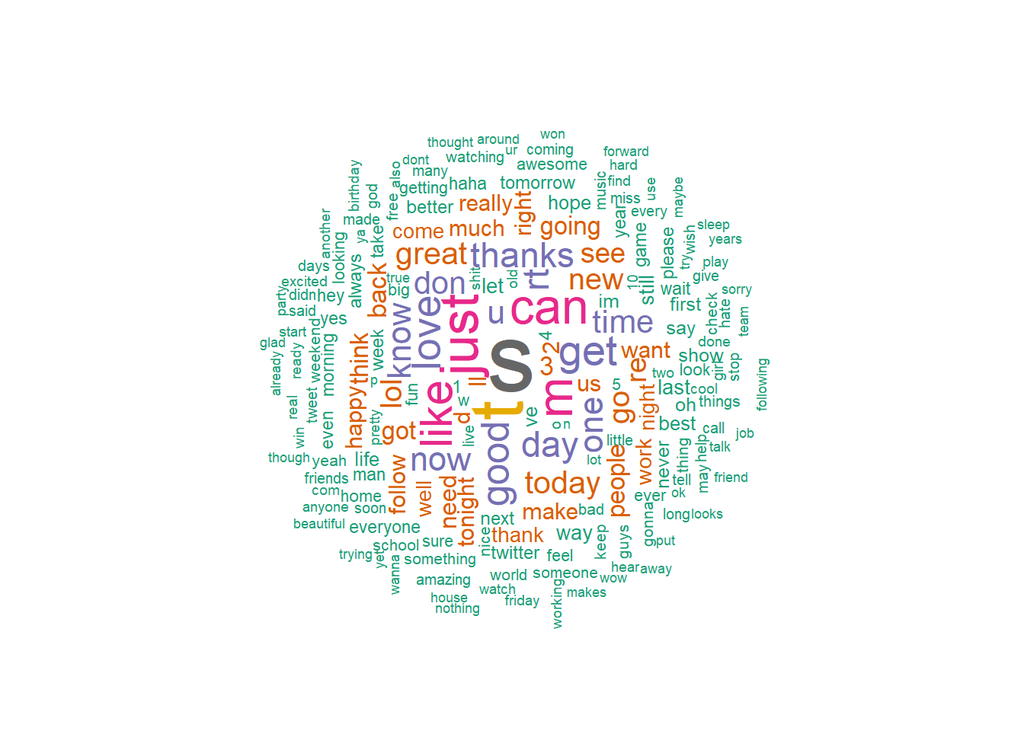

```r
wordcloud(words = twitterVocab$term, freq = twitterVocab$term_count, min.freq = 1,
          max.words=200, random.order=FALSE, rot.per=0.35, scale = c(4,0.4),
          colors=brewer.pal(8, "Dark2"))
```

## Blogs Wordcloud

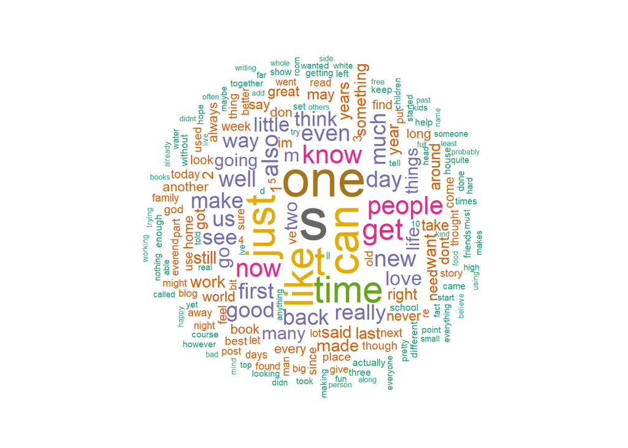

```r
blogsIoK <- itoken(blogsTrain,
                   preprocessor = tolower,
                   tokenizer = tokenize_words,
                   progressbar = FALSE)

blogsVocab <- create_vocabulary(blogsIoK, stopwords = stopwords())

wordcloud(words = blogsVocab$term, freq = blogsVocab$term_count, min.freq = 1,
          max.words=200, random.order=FALSE, rot.per=0.35, scale = c(4,0.2),
          colors=brewer.pal(8, "Dark2"))
```

## News Wordcloud

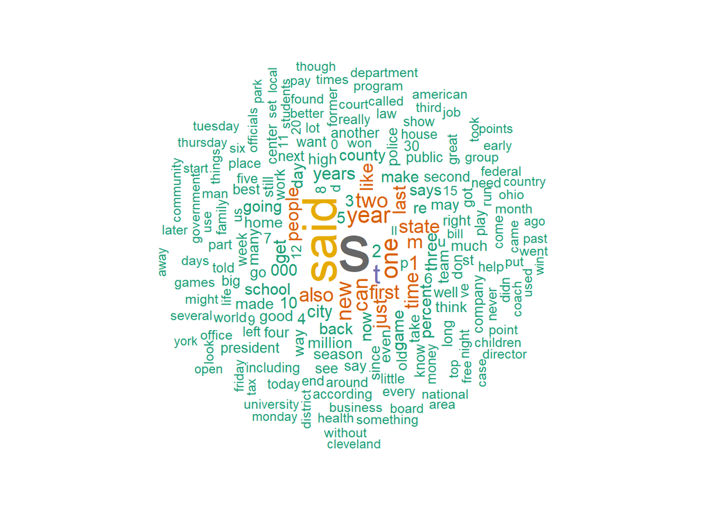

```r
newsIoK <- itoken(newsTrain,
                  preprocessor = tolower,
                  tokenizer = tokenize_words,
                  progressbar = FALSE)

newsVocab <- create_vocabulary(newsIoK, stopwords = stopwords())

wordcloud(words = newsVocab$term, freq = newsVocab$term_count, min.freq = 1,
          max.words=200, random.order=FALSE, rot.per=0.35, scale = c(4,0.65),
          colors=brewer.pal(8, "Dark2"))
```

## Twitter Words Summary Without Stopwords

#### Words’ Appearances in Dcouments

This summary shows that for the most common word, it has appeared in 222748 tweets.

```r
class(twitterVocab) <- "data.frame"
summary(twitterVocab$doc_count)
```

```
##      Min.   1st Qu.    Median      Mean   3rd Qu.      Max.
##      1.00      1.00      1.00     49.56      4.00 222748.00
```

#### Number of Unique Words

```r
print(nrow(twitterVocab))
```

```
## [1] 288737
```

## Blogs Words Summary Without Stopwords

#### Words’ Appearances in Dcouments

```r
class(blogsVocab) <- "data.frame"
summary(blogsVocab$doc_count)
```

```
##     Min.  1st Qu.   Median     Mean  3rd Qu.     Max.
##     1.00     1.00     1.00    54.52     5.00 83401.00
```

#### Number of Unique Words

```r
print(nrow(blogsVocab))
```

```
## [1] 265617
```

## News Words Summary Without Stopwords

#### Words’ Appearances in Dcouments

```r
class(newsVocab) <- "data.frame"
summary(newsVocab$doc_count)
```

```
##      Min.   1st Qu.    Median      Mean   3rd Qu.      Max.
##      1.00      1.00      2.00     74.23      8.00 224441.00
```

#### Number of Unique Words

```r
print(nrow(newsVocab))
```

```
## [1] 215024
```

# Next Step

With the above frequency count, we have seen some of the characteristics of the word usage in different dataset. Since our final project will be predicting the next word based on the input of the user, I will consider n-grams to include a number of words instead of just a single word.